# Bitcoin Sentiment Analysis Pre / Post Covid

## Collaborators: Rohan Bhatt & Nimay Vyas

## Introduction To Cryptocurrency

Cryptocurrency, a revolutionary concept that emerged with the advent of Bitcoin in 2009, is a digital or virtual form of money that utilizes cryptographic techniques for secure transactions and control of new unit creation. Unlike traditional currencies issued and regulated by governments and central banks, cryptocurrencies operate on decentralized networks based on blockchain technology. Blockchain is a distributed ledger that records all transactions across a network of computers, ensuring transparency, immutability, and security. Each cryptocurrency, represented by unique tokens, functions within its own ecosystem, and ownership is validated through cryptographic keys. These keys, comprising a public address and a private key, enable users to send and receive transactions securely. Cryptocurrencies have sparked a global wave of innovation, introducing new possibilities for financial systems, digital assets, and even programmable contracts called smart contracts. Their potential impact ranges from transforming the way we conduct financial transactions to enabling decentralized applications that operate independently from intermediaries.

The cryptocurrency landscape has expanded significantly beyond Bitcoin, with thousands of different cryptocurrencies introduced, each with varying purposes, technologies, and features. Ethereum, for instance, introduced the concept of smart contracts, enabling developers to build decentralized applications atop its blockchain. Ripple aimed to facilitate seamless cross-border payments, while Litecoin offered faster transaction confirmation times. The market's volatility, coupled with regulatory challenges and security concerns, has generated debate about the future of cryptocurrencies and their role in the global economy. As of my last update in September 2021, governments and financial institutions were grappling with how to integrate cryptocurrencies into existing regulatory frameworks while harnessing their potential benefits for efficiency, inclusivity, and innovation in the financial sector.

## What is Bitcoin?

Bitcoin was introduced in 2009 by anyonymous person known as Satoshi Nakamoto is the the most popular cryptocurrency. Bitcoin laid the foundation for the entire digital currency ecosystem. It operates as a decentralized digital currency and is designed to enable peer-to-peer transactions without the need for intermediaries like banks or payment processors. At its core, Bitcoin relies on a technology called blockchain, which records all transactions ever conducted with the cryptocurrency. Transactions are verified by a network of miners who use computational power to solve complex mathematical puzzles, thereby confirming and adding new transactions to the blockchain.

A distinctive aspect of Bitcoin is its fixed supply. Only 21 million Bitcoins will ever exist, a scarcity that contrasts with traditional fiat currencies subject to central bank manipulation. This limited supply has contributed to Bitcoin's reputation as "digital gold" and a store of value. Additionally, Bitcoin's decentralized nature and cryptographic security provide a level of anonymity and security for users. Over the years, Bitcoin has gained immense attention, both as an investment vehicle and as a technological innovation that challenges traditional financial systems. Its price volatility, potential to disrupt established financial institutions, and the ongoing debate about its long-term viability and regulatory implications have fueled discussions across industries and governments globally.

## Purpose Of Our Project

The purpose of our project is to disect the sentiment around the discussions mentioned in the paragraph above. Bitcoin has been around since 2009 but reached an all time high of $68,789.63 on April 14, 2021. It is currently trading at $26,129.90 (as of 8/20/2023). The spike in Bitcoin pricing happened during the COVID-19 pandemic and it has then cooled down significantly. Throughout the scope of this project we aim to analzyze the sentiment surrounding Bitcoin, specifically pre and post pandemic by analyzing tweets and correlating them to the price of Bitcoin.

To achieve this we are analyzing over a million data points provide to us via kaggle.com: https://www.kaggle.com/datasets/prkhrawsthi/bitcoin-usd-daily-price-with-volume-2015-2023 https://www.kaggle.com/datasets/kaushiksuresh147/bitcoin-tweets

We have broken up this project into 5 parts: Data Collection, Parsing, and Cleaning Exploratory Data Analysis Sentiment Analysis Preperation Sentiment Analysis Overview Result Interpretation

Through these five parts, we aim to take you through the entire pipeline of data science and apply what we have learned in class to a real world problem. We hope that our project will help provide you insight into the sentiment surrounding cryptocurrency and the impact a major world event can have on it.

Twitter is a huge platform and has been around since 2006, thus we will be looking at tweets related to crypto currency. Below is the Data Curation / Parsing / Management.

## Part 1: Data Collection, Parsing, and Cleaning

In this area of the project we are going to be looking into the datasets that we derive from kaggle.com more specifically the "bitcoin-tweets" dataset. This data set derives tweets from the Twitter platform with the #Bitcoin and #btc hash tags. This dataset has curated over a million datapoints. For our filtered data frame, we decided to include a variety of columns including user_name, user_location, user_description user_created, user_followers, user_friends, user_favourites, user_verified, date, text, hashtag, source, and is_retweet. Through the use of these metrics we aim to analyze the sentiment surrounding these tweets. Additionally after curating the data, we also drop duplicates and handle missing values with aim of cleaning our datafram.

```python
# Libraries
import pandas as pd
import re
import matplotlib.pyplot as plt
import seaborn as sns
import nltk
from textblob import TextBlob
from wordcloud import WordCloud
import dask.dataframe as dd
import numpy as np

# Read and clean the dataset
nltk.download('stopwords')
# Load the dataset
df = pd.read_csv('Bitcoin_tweets.csv', nrows=5000000)

# Drop duplicates
df.drop_duplicates(inplace=True)

# Handle missing values
df.fillna({
    'user_name': 'unknown',
    'user_location': 'unknown',
    'user_description': 'unknown',
    # ... Add other columns if necessary
}, inplace=True)

# # Clean the text column
# df['text'] = df['text'].str.replace(r'[^a-zA-Z0-9\s]', '', regex=True)

# # Convert the date column to a datetime format
# df['date'] = pd.to_datetime(df['date'], errors='coerce')

# # Extract and clean the hashtags column (assuming they are comma-separated)
# df['hashtags'] = df['hashtags'].str.split(',')
# df['hashtags'] = df['hashtags'].apply(lambda x: [s.strip() for s in x] if isinstance(x, list) else x)


df.head()
```

|  | user_name | user_location | user_description | user_created | user_followers | user_friends | user_favourites | user_verified | date | text | hashtags | source | is_retweet |
| --- | --- | --- | --- | --- | --- | --- | --- | --- | --- | --- | --- | --- | --- |
| 0 | DeSota Wilson | Atlanta, GA | Biz Consultant, real estate, fintech, startups... | 2009-04-26 20:05:09 | 8534.0 | 7605 | 4838 | False | 2021-02-10 23:59:04 | Blue Ridge Bank shares halted by NYSE after #b... | ['bitcoin'] | Twitter Web App | False |
| 1 | CryptoND | unknown | 😎 BITCOINLIVE is a Dutch platform aimed at inf... | 2019-10-17 20:12:10 | 6769.0 | 1532 | 25483 | False | 2021-02-10 23:58:48 | 😎 Today, that's this #Thursday, we will do a "... | ['Thursday', 'Btc', 'wallet', 'security'] | Twitter for Android | False |
| 2 | Tdlmatias | London, England | IM Academy : The best #forex, #SelfEducation, ... | 2014-11-10 10:50:37 | 128.0 | 332 | 924 | False | 2021-02-10 23:54:48 | Guys evening, I have read this article about B... | NaN | Twitter Web App | False |
| 3 | Crypto is the future | unknown | I will post a lot of buying signals for BTC tr... | 2019-09-28 16:48:12 | 625.0 | 129 | 14 | False | 2021-02-10 23:54:33 | $BTC A big chance in a billion! Price: \487264... | ['Bitcoin', 'FX', 'BTC', 'crypto'] | dlvr.it | False |
| 4 | Alex Kirchmaier 🇦🇹🇸🇪 #FactsSuperspreader | Europa | Co-founder @RENJERJerky \| Forbes 30Under30 \| I... | 2016-02-03 13:15:55 | 1249.0 | 1472 | 10482 | False | 2021-02-10 23:54:06 | This network is secured by 9 508 nodes as of t... | ['BTC'] | Twitter Web App | False |

## Part 2: Exploratory Data Analysis (EDA)

Before we go deeper into sentiment analysis, it is important for us to understand both the structure and charecteristics of our current datasets. To do this, we need to indentify the primary features of our data set, analyze the distribution of tweets over time, and get a general feel of the provided user engagement metrics.

In part two we will be exploring:

- The distribution of tweets across time.
- The most active users and their characteristics.
- The distribution of user account creation dates, providing insights into the influx of new users over time.
- The distribution of tweets based on user verification status.

Let's jump right into it!

[output not shown]

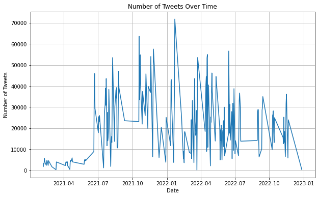

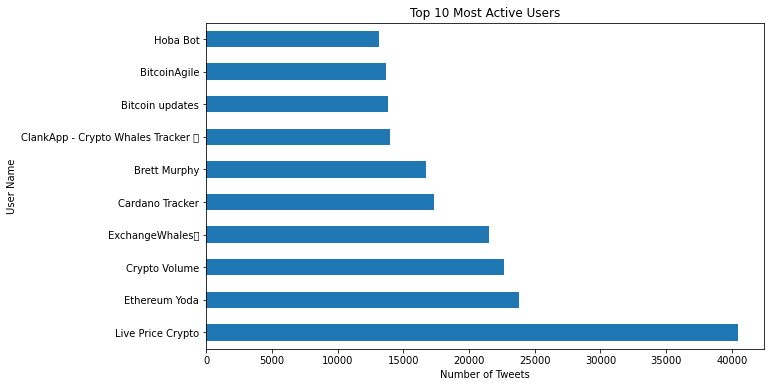

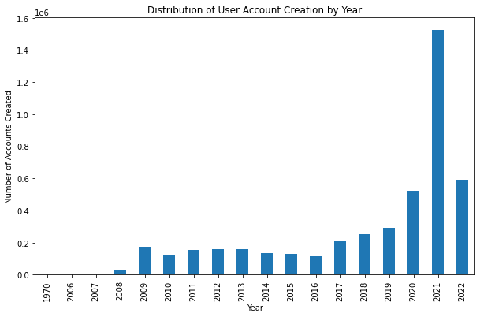

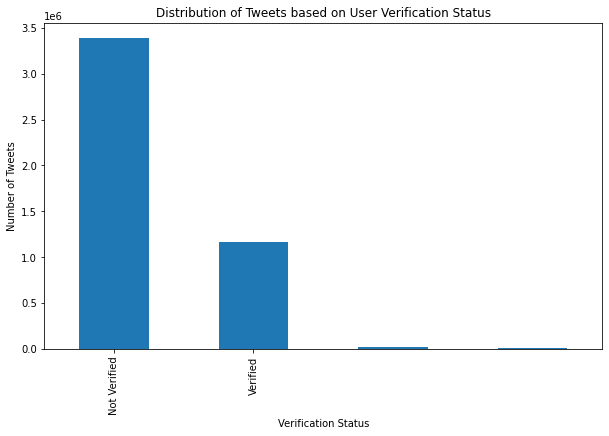

```python
# Convert the 'date' column to datetime format
print(df['date'].iloc[64943])

df['date'] = pd.to_datetime(df['date'], errors='coerce')
df = df.dropna(subset=['date'])

# Plot distribution of tweets over time
plt.figure(figsize=(10,6))
df.groupby(df['date'].dt.date).size().plot()
plt.title('Number of Tweets Over Time')
plt.xlabel('Date')
plt.ylabel('Number of Tweets')
plt.grid(True)
plt.show()

# Top 10 most active users
top_users = df['user_name'].value_counts().head(10)
plt.figure(figsize=(10,6))
top_users.plot(kind='barh')
plt.title('Top 10 Most Active Users')
plt.xlabel('Number of Tweets')
plt.ylabel('User Name')
plt.show()

# Distribution of user account creation dates
df['user_created'] = pd.to_datetime(df['user_created'])
plt.figure(figsize=(10,6))
df.groupby(df['user_created'].dt.year).size().plot(kind='bar')
plt.title('Distribution of User Account Creation by Year')
plt.xlabel('Year')
plt.ylabel('Number of Accounts Created')
plt.show()

# Tweets distribution based on user verification status
verified_counts = df['user_verified'].value_counts()
plt.figure(figsize=(10,6))
verified_counts.plot(kind='bar')
plt.xticks([0,1], ['Not Verified', 'Verified'])
plt.title('Distribution of Tweets based on User Verification Status')
plt.xlabel('Verification Status')
plt.ylabel('Number of Tweets')
plt.show()
```

### Part 2 Analysis:

We start of part two by converting the date to a date time format. We then generate four different plots:

- Number of Tweets Over Time
- Top 10 Active Users
- Distribution Of User Account Creation Over Time
- Distribution Of Tweets Based On User Verification Status

- May 2021: The COVID-19 pandemic was starting to peak in many countries. This led to increased uncertainty and volatility in the global financial markets, which may have contributed to the increase in interest in Bitcoin as a safe haven asset.
- October 2021: The first Bitcoin ETF was launched in the United States. This may have also contributed to the increase in interest in Bitcoin, as it made it easier for investors to buy and sell Bitcoin.
- December 2021: China banned Bitcoin mining. This may have led to a decline in the supply of Bitcoin, which may have contributed to the increase in price.
- January 2022: The Omicron variant of COVID-19 emerged. This led to renewed uncertainty and volatility in the global financial markets, which may have contributed to the decline in the price of Bitcoin. June 2022: The TerraUSD stablecoin collapsed. This led to a decline in confidence in the cryptocurrency market, which may have also contributed to the decline in the price of Bitcoin.
- July 2022: The Celsius Network, a cryptocurrency lending platform, halted withdrawals. This led to further concerns about the stability of the cryptocurrency market, which may have also contributed to the decline in the price of Bitcoin.

It is important to note that these are just a few possible explanations, and the actual reasons for the increase and decline in the number of tweets with a Bitcoin related hashtag from 2021 to 2023 are complex and cannot be definitively determined. More research is needed to understand the relationship between the pandemic and the interest in Bitcoin. Overall, the graph suggests that there was a significant increase in interest in Bitcoin during the COVID-19 pandemic. However, it is difficult to say definitively whether the pandemic was the main factor in this increase. More research is needed to understand the relationship between the pandemic and the interest in Bitcoin

The fourth graph shows the number of tweets that came from verified versus non-verified accounts. The verified accounts are those that have been authenticated by Twitter as belonging to real people or organizations. The non-verified accounts are those that have not been authenticated. The graph shows that the number of tweets from non-verified accounts is significantly higher than the number of tweets from non-verified accounts. This is likely because there are a lot less verified accounts as opposed to non verified accounts. Additionally, some of these non verified accounts follow the verified accounts from which they can subtweet.

## Part 3: Sentiment Analysis Preparation

The previous section acquianted us with the basic features of our dataset. Now that we are familiar with the ins and outs and have an idea of the generic trends surrounding tweets and bitcoin sentiment, we can now start with outr sentiment analysis. To do sentiment analysis, we are going to have to analyze the text from the tweets that he have previously filterted. This textual data contains alot of noise such as URL's, special characters, and numbers that we are going to have to decipher through. This will help prepare our graph for sentiment analysis.

Throughout the duration of Part 3, we will do the following:

- Clean the tweet text by removing unnecessary noise.
- Tokenize the cleaned text.
- Visualize the most common words in our tweet corpus.
- Implement sentiment analysis to classify tweets as positive, negative, or neutral.

Let's begin our sentiment analysis preperation!

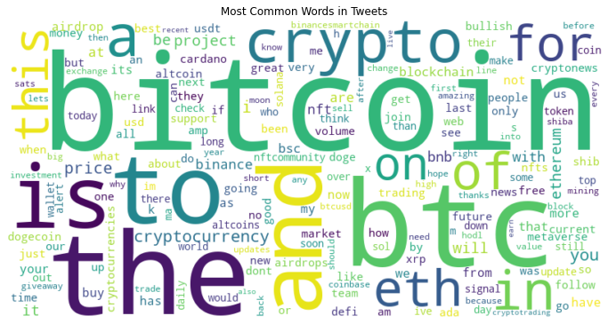

```python
import re
from collections import Counter
from wordcloud import WordCloud
from textblob import TextBlob

# 1. Clean the tweet text
def clean_text(text):
    text = re.sub(r'http\S+', '', text)  # Remove URLs
    text = re.sub(r'@\S+', '', text)     # Remove mentions
    text = re.sub(r'#', '', text)        # Remove hashtags
    text = re.sub(r'[^a-zA-Z\s]', '', text)  # Remove punctuations and numbers
    return text.lower().strip()

df['cleaned_text'] = df['text'].apply(clean_text)

# 2. Tokenize the cleaned text
df['tokens'] = df['cleaned_text'].apply(lambda x: x.split())

# 3. Visualize the most common words
all_words = [word for tokens in df['tokens'] for word in tokens]
word_freq = Counter(all_words)
wordcloud = WordCloud(width=800, height=400, background_color='white').generate_from_frequencies(word_freq)

plt.figure(figsize=(12, 8))
plt.imshow(wordcloud, interpolation='bilinear')
plt.axis('off')
plt.title('Most Common Words in Tweets')
plt.show()

# 4. Implement sentiment analysis
def get_sentiment(text):
    analysis = TextBlob(text)
    if analysis.sentiment.polarity > 0:
        return 'positive'
    elif analysis.sentiment.polarity < 0:
        return 'negative'
    else:
        return 'neutral'

df['sentiment'] = df['cleaned_text'].apply(get_sentiment)
```

### Part 3 Analysis:

In the above code, we are simply preparing our graph for sentiment analysis. In doing so, we are removing outside noise from our tweets. We start of by removing URLs, mentions, hashtags, and punctuations/numbers as all of these factors are not going to have to do with sentiment towards bitcoin. In removing these sentiments, we are able to curate the tweets to just text. We then tokenize the cleaned text and it is now ready for sentiment analysis.

We generate a visualiztion of the most common words as well. There are some filler words in there but some of the most prominent words include btc, bitcoin, ethereum, blockchain, cryptocurrency, and other crypto related terms. There is no noise in the visualization which shows that our data is now ready for sentiment analysiz.

## Part 4: Sentiment Analysis Overview

Now that we have a clean and prepared dataset, let's go ahead and get a broader perspective on the sentiments of the tweets related to bitcoing. This sentiment analysis overview will help us dive deeper into the general mood of the Twitter community regarding Bitcoin, more specifcally in the context of the pre versus post covid era.

Throughout the duration of Part 3, we will do the following:

- Analyze the distribution of tweet sentiments (positive, negative, neutral) in the dataset.
- Compare sentiments of tweets before COVID (pre-March 2020) with those during and post the COVID era.
- Visualize sentiment trends over time.
- Such analyses can offer insights into how external events, like a global pandemic, might influence public sentiment toward certain topics or assets, such as Bitcoin.

Let's conduct a sentiment analysis!

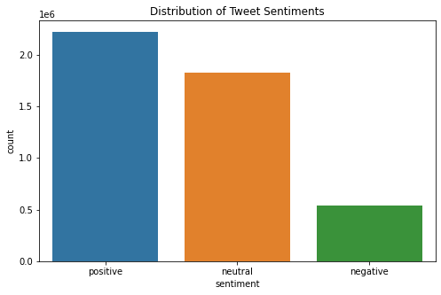

[figure not shown]

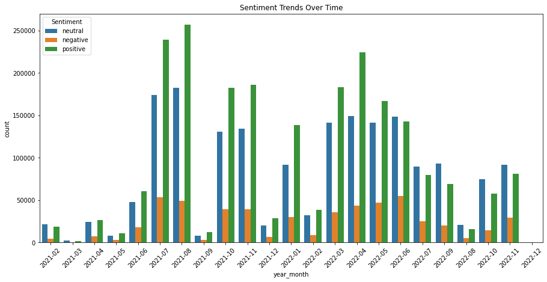

```python
import seaborn as sns
import matplotlib.dates as mdates

# 1. Distribution of sentiments
plt.figure(figsize=(8, 5))
sns.countplot(x='sentiment', data=df, order=['positive', 'neutral', 'negative'])
plt.title('Distribution of Tweet Sentiments')
plt.show()

# Extract year-month from date for trend analysis
df['date'] = pd.to_datetime(df['date'])
df['year_month'] = df['date'].dt.to_period('M')

# 2. Compare sentiments pre and post COVID
pre_covid = df[df['date'] < '2020-03-01']
post_covid = df[df['date'] >= '2020-03-01']

# Plotting sentiments before and after COVID
fig, axes = plt.subplots(1, 2, figsize=(15, 5))

sns.countplot(x='sentiment', data=pre_covid, ax=axes[0], order=['positive', 'neutral', 'negative'])
axes[0].set_title('Sentiment Distribution Pre-COVID')

sns.countplot(x='sentiment', data=post_covid, ax=axes[1], order=['positive', 'neutral', 'negative'])
axes[1].set_title('Sentiment Distribution Post-COVID')

plt.tight_layout()
plt.show()

# 3. Sentiment trends over time
plt.figure(figsize=(15, 7))
sns.countplot(x='year_month', hue='sentiment', data=df)
plt.xticks(rotation=45)
plt.title('Sentiment Trends Over Time')
plt.legend(title='Sentiment', loc='upper left')
plt.show()
```

### Part 4 Analysis:

Using the above graph we generate three different crypto graphs. Due to data limitations, a pre-covid graph was unable to be generated due to data limitations. However, let's dive deeper and analyze all three of the graphs. The first graph shows the cumulative sentiment analysis of tweets that used the #bitcoin and #btc from 02/2021 to 01/2023. To do this we use the polarity analysis from part 4 to assign tweets a positive, negative, or neutral connotation. In doing this, we are able to tack the sentiment. The first graph shows that overall based off of polarity, the sentiment generated was more positive or neutral as opposed to negative overall. This could be because overall there has been a lot of postivity surrounding cryptocurrency. The second graph can be mitigated as we did not have the resources to compute pre covid data for sentiment analysis. The third graph is the most important one however. We are able to see spikes and down trends on a monthly basis from 02/2021 to 11/22. For the most part, the positive and neutral tweets significantly outweigh the negative tweets. This shows that there is not a lot of negative sentiment surrounding cryptocurrency. There has been more of a rise in neutral sentiment as of 11/22 however, the trend has more often then not been overwhelmingly positive.

This goes to show that throughout the duration and post pandemic, there has been a lot of support for cryptocurrency. The high that we experienced in April 2021 of $69,000 has done nothing but garnered positivity for cyrptocurrency. However, one thing to be noted is that the graph does follow a bell curve and towards the end of the graph, you can see that there is a decline in the amount of tweets regarding cryptocurrency showing that it may be losing popularity.

## Part 5: Correlating Sentiment with Bitcoin Price

The flow of cryptocurrencies often find themselves influenced by the sentiments and moods of their stakeholders. Bitcoin, as a forerunner in this space, becomes an especially pertinent subject to analyze. By inspecting how sentiment metrics sway alongside Bitcoin's valuation, we aim to unearth any palpable ties between public sentiment and market performance.

To commence, our expedition involves:

Merging Data Streams: A fusion of sentiment scores with real-time Bitcoin pricing charts will serve as our foundational dataset. Statistical Insight: With our integrated dataset, we'll deploy statistical tools to decipher the depth of correlation between sentiment oscillations and Bitcoin's price movements. Narrative through Visualization: Trends, when charted, breathe life into numbers. By juxtaposing sentiment scores and Bitcoin's pricing graph, we aim to paint the broader picture of their interplay across time. For all stakeholders, be it savvy investors, inquisitive researchers, or crypto aficionados, this correlation can offer a unique vantage point into the mystique of cryptocurrency market dynamics.

```python
# Load BTC-USD.csv into a DataFrame
df_price = pd.read_csv("BTC-USD.csv")
print(df_price.head())

# Convert 'Date' column to datetime and extract year_month
df_price['Date'] = pd.to_datetime(df_price['Date'])
df_price['year_month'] = df_price['Date'].dt.to_period('M')

# Aggregate price data to get average monthly closing price
df_price_agg = df_price.groupby('year_month').agg({
    'Close': 'mean'  # Average monthly closing price
}).reset_index()

df['year_month'] = df['date'].dt.to_period('M')  # Make sure you have the year_month column
df['positive'] = (df['sentiment'] == 'positive').astype(int)
df['neutral'] = (df['sentiment'] == 'neutral').astype(int)
df['negative'] = (df['sentiment'] == 'negative').astype(int)

# Aggregate sentiment data to get monthly counts
df_sentiment_agg = df.groupby('year_month').agg({
    'positive': 'sum',
    'neutral': 'sum',
    'negative': 'sum'
}).reset_index()

df_merged = pd.merge(df_sentiment_agg, df_price_agg, on='year_month', how='inner')
print(df_merged.head())
```

```
         Date        Open        High         Low       Close   Adj Close  \
0  2015-01-03  314.846008  315.149994  281.082001  281.082001  281.082001
1  2015-01-04  281.145996  287.230011  257.612000  264.195007  264.195007
2  2015-01-05  265.084015  278.341003  265.084015  274.473999  274.473999
3  2015-01-06  274.610992  287.553009  272.696014  286.188995  286.188995
4  2015-01-07  286.076996  298.753998  283.079010  294.337006  294.337006

     Volume
0  33054400
1  55629100
2  43962800
3  23245700
4  24866800
  year_month  positive  neutral  negative         Close
0    2021-02     18867    21409      4167  46306.798968
1    2021-03      1745     1994       401  54998.008695
2    2021-04     26194    24399      7467  57206.720052
3    2021-05     10544     8255      2983  46443.286668
4    2021-06     60350    47551     17894  35845.154688
```

After finally getting the data of bitcoin prices and sentiment according to date, below are graphs visualizing them

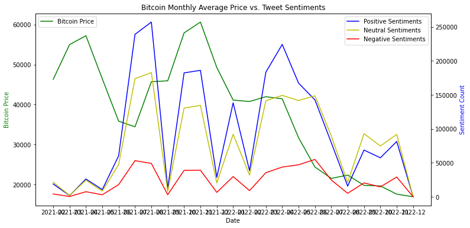

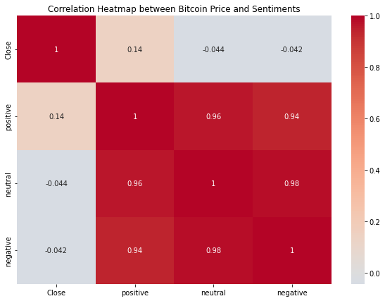

```python
import matplotlib.pyplot as plt
import seaborn as sns
df_merged['year_month'] = df_merged['year_month'].astype(str)

fig, ax1 = plt.subplots(figsize=(12, 6))

# Twin the axes
ax2 = ax1.twinx()

# Plotting
ax1.plot(df_merged['year_month'], df_merged['Close'], color='g', label='Bitcoin Price')
ax2.plot(df_merged['year_month'], df_merged['positive'], color='b', label='Positive Sentiments')
ax2.plot(df_merged['year_month'], df_merged['neutral'], color='y', label='Neutral Sentiments')
ax2.plot(df_merged['year_month'], df_merged['negative'], color='r', label='Negative Sentiments')

# Set the Y axis labels
ax1.set_ylabel('Bitcoin Price', color='g')
ax2.set_ylabel('Sentiment Count', color='b')

ax1.set_xlabel('Date')
ax1.set_title('Bitcoin Monthly Average Price vs. Tweet Sentiments')

# Legends
ax1.legend(loc='upper left')
ax2.legend(loc='upper right')

# Display the plot
plt.show()

# ------------------------------

# Compute the correlation matrix
correlation_matrix = df_merged[['Close', 'positive', 'neutral', 'negative']].corr()

plt.figure(figsize=(10, 7))
sns.heatmap(correlation_matrix, annot=True, cmap='coolwarm', center=0)
plt.title("Correlation Heatmap between Bitcoin Price and Sentiments")
plt.show()
```

### Part 5 Analysis

Here are some other things to note about the first graph:

## Part 6: Analyzing the Correlation

Now that we have visualized the data, it's essential to understand the relationship, if any, between Bitcoin's price and the sentiment of tweets. One of the simplest statistical tools at our disposal is Pearson's correlation coefficient. Pearson's correlation coefficient is a measure of linear correlation between two sets of data. It can be between -1 and 1. A value of 1 implies a perfect positive correlation, a value of -1 implies a perfect negative correlation, and a value of 0 implies no linear correlation.

Let's calculate this coefficient for Bitcoin's price in relation to the positive, neutral, and negative sentiments.

```python
correlations = df_merged[['Close', 'positive', 'neutral', 'negative']].corr()

print("Correlation between Bitcoin Price and Positive Sentiments:", correlations['Close']['positive'])
print("Correlation between Bitcoin Price and Neutral Sentiments:", correlations['Close']['neutral'])
print("Correlation between Bitcoin Price and Negative Sentiments:", correlations['Close']['negative'])
```

```
Correlation between Bitcoin Price and Positive Sentiments: 0.13751052206520778
Correlation between Bitcoin Price and Neutral Sentiments: -0.04424391062672568
Correlation between Bitcoin Price and Negative Sentiments: -0.04175029161723547
```

## Part 7: Predictive Modeling

Having visualized and identified potential correlations, we can now look into creating a predictive model. Predictive modeling will help us determine if the sentiment of tweets can be a predictor for Bitcoin price movement.

```python
#Feature Engineering and Data Preprocessing:

# Before building our model, we need to ensure our data is suitable for a machine learning algorithm:

# Convert year_month back to a numerical feature (the number of months since the first month)
# Convert 'year_month' to integer format where each month is represented by the number of months since the first month
# Convert 'year_month' back to datetime format
# Convert 'year_month' from string back to Period
df_merged['year_month'] = df_merged['year_month'].apply(pd.Period)

# Convert 'year_month' back to datetime format
df_merged['year_month_dt'] = df_merged['year_month'].apply(lambda x: x.start_time)

# Convert 'year_month' to integer format where each month is represented by the number of months since the first month
df_merged['month_since_start'] = (df_merged['year_month_dt'].dt.year - df_merged['year_month_dt'].min().year) * 12 + df_merged['year_month_dt'].dt.month - df_merged['year_month_dt'].min().month

# Drop the auxiliary 'year_month_dt' column
df_merged.drop('year_month_dt', axis=1, inplace=True)

# Now proceed with the rest of the code
X = df_merged[['positive', 'neutral', 'negative', 'month_since_start']]
y = df_merged['Close']
```

Now that we've properly formatted our features in the dataframe, we can continue by splitting the data into training and testing sets and then training a regression model to see if there's any correlation between sentiment and Bitcoin price.

```python
from sklearn.model_selection import train_test_split
from sklearn.linear_model import LinearRegression
from sklearn.metrics import mean_squared_error, r2_score

# Split the data into training and testing sets
X_train, X_test, y_train, y_test = train_test_split(X, y, test_size=0.2, random_state=42)

# Initialize a Linear Regression model
regressor = LinearRegression()

# Train the model on the training data
regressor.fit(X_train, y_train)

# Predict Bitcoin prices for the test set
y_pred = regressor.predict(X_test)

# Calculate and print the R^2 and RMSE
print("R^2 score:", r2_score(y_test, y_pred))
print("RMSE:", np.sqrt(mean_squared_error(y_test, y_pred)))
```

```
R^2 score: 0.37654697653115954
RMSE: 11870.304974964381
```

## Part 8: Visualization and Interpretation

With the model trained, it's important to visualize our predictions against the actual values to get a sense of how well our model is performing.

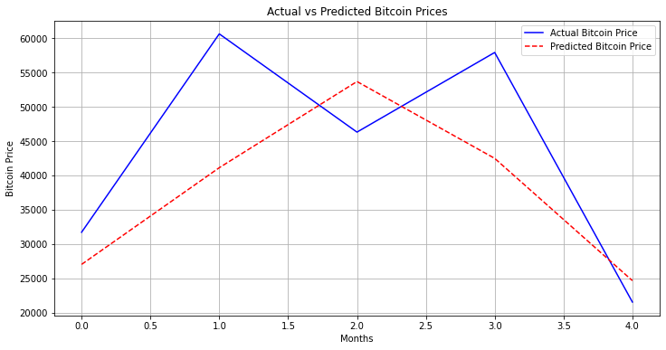

```python
# Create a new DataFrame for visualization
df_results = pd.DataFrame({
    'Actual': y_test,
    'Predicted': y_pred
})

# Reset index for visualization purposes
df_results.reset_index(drop=True, inplace=True)

# Plot actual vs predicted
plt.figure(figsize=(12, 6))
plt.plot(df_results['Actual'], label='Actual Bitcoin Price', color='blue')
plt.plot(df_results['Predicted'], label='Predicted Bitcoin Price', color='red', linestyle='dashed')
plt.title('Actual vs Predicted Bitcoin Prices')
plt.xlabel('Months')
plt.ylabel('Bitcoin Price')
plt.legend()
plt.grid(True)
plt.show()
```

### Part 8 Analysis

The Bitcoin market is very volatile, and prices can fluctuate wildly in a short period of time. This makes it difficult to predict the future price of Bitcoin with any accuracy. The predictive model used in this graph was trained on our sentiment data that did not accurately reflect the current volatility of the market.

Another reason why the predictive model may have been inaccurate is that it did not take into account all of the factors that can affect the price of Bitcoin. These factors include:

- Economic news
- Regulatory changes
- Technical developments
- Speculation
- Investor sentiment

Due to these various factors the model we trained was not able to accurately predict the prices. This shows that the prices predicted by our sentiments are not a great indicator and should not be used to predict prices. However, it is very interesting to see that at times there are simalarities and the graphs both do end neer at the same point.

## Part 9 - Conclusion:

Growing up with the internet, We've always been drawn to data science due to its correlation with my other hobbies of video games and technology. Bitcoin is and always has been a huge buzzword going around due to its fluctuation in price and value as an investment. We always thought "what makes Bitcoin so unpredictable?", with these questions in mind, we seeked out a way to find the correlation of real life events / time to the sentiment and price of Bitcoin due to it being the highest valued and most popular crypto currency.